# Uso del clasificador del vecino más próximo (K-Nearest Neighbor)

En esta práctica vamos a usar un KNN con los datos públicos para diagnóstico de cáncer de pecho de la universidad de Winsconsin. Veremos cómo usar KNN como un clasificador y estudiaremos cómo ajustar su parámetro K a este dataset.

Para consultar detalles acerca de las características que forman los datos, puedes consultar el artículo original de los autores que construyeron el dataset: 'Nuclearfeature extraction for tumos diagnosis. Street, W. et al Technical report 1992.' incluído en los materiales de la práctica.

Notación: CUando veas en el cuaderno el símbolo **(¿?)** significa que consultes la ayuda online del paquete de python correspondiente

Andreu Cantó Belda y Amparo Gálvez Vilar

```python
#Importamos los paquetes necesarios

import numpy as np # linear algebra
import pandas as pd # data processing, CSV file I/O (e.g. pd.read_csv)
import matplotlib.pyplot as plt # for data visualization purposes
import seaborn as sns # for data visualization
from sklearn import preprocessing
from sklearn.model_selection import train_test_split
from sklearn.neighbors import KNeighborsClassifier
from sklearn.metrics import accuracy_score, precision_score, recall_score
from sklearn.model_selection import cross_val_score

%matplotlib inline
```

Primero bájate de aula virtual el fichero zip con el dataset y colócalo en un directorio (ej. 'data). Lee el csv que se te proporciona y cárgalo en un panda dataframe. Llama a la variable tipo Dataframe '**df**'

```python
datafile = './data/data_breast_cancer.csv'

df = pd.read_csv(datafile)

df.head()
```

|  | id | diagnosis | radius_mean | texture_mean | perimeter_mean | area_mean | smoothness_mean | compactness_mean | concavity_mean | concave points_mean | ... | texture_worst | perimeter_worst | area_worst | smoothness_worst | compactness_worst | concavity_worst | concave points_worst | symmetry_worst | fractal_dimension_worst | Unnamed: 32 |
| --- | --- | --- | --- | --- | --- | --- | --- | --- | --- | --- | --- | --- | --- | --- | --- | --- | --- | --- | --- | --- | --- |
| 0 | 842302 | M | 17.99 | 10.38 | 122.80 | 1001.0 | 0.11840 | 0.27760 | 0.3001 | 0.14710 | ... | 17.33 | 184.60 | 2019.0 | 0.1622 | 0.6656 | 0.7119 | 0.2654 | 0.4601 | 0.11890 | NaN |
| 1 | 842517 | M | 20.57 | 17.77 | 132.90 | 1326.0 | 0.08474 | 0.07864 | 0.0869 | 0.07017 | ... | 23.41 | 158.80 | 1956.0 | 0.1238 | 0.1866 | 0.2416 | 0.1860 | 0.2750 | 0.08902 | NaN |
| 2 | 84300903 | M | 19.69 | 21.25 | 130.00 | 1203.0 | 0.10960 | 0.15990 | 0.1974 | 0.12790 | ... | 25.53 | 152.50 | 1709.0 | 0.1444 | 0.4245 | 0.4504 | 0.2430 | 0.3613 | 0.08758 | NaN |
| 3 | 84348301 | M | 11.42 | 20.38 | 77.58 | 386.1 | 0.14250 | 0.28390 | 0.2414 | 0.10520 | ... | 26.50 | 98.87 | 567.7 | 0.2098 | 0.8663 | 0.6869 | 0.2575 | 0.6638 | 0.17300 | NaN |
| 4 | 84358402 | M | 20.29 | 14.34 | 135.10 | 1297.0 | 0.10030 | 0.13280 | 0.1980 | 0.10430 | ... | 16.67 | 152.20 | 1575.0 | 0.1374 | 0.2050 | 0.4000 | 0.1625 | 0.2364 | 0.07678 | NaN |

5 rows × 33 columns

Eliminamos las columnas etiquetadas como 'id' y 'Unnamed: 32' ya que no aportan información. Ojo al espacio en blanco despues de ':' en Unnamed.

**(¿?)** Usa para ello el método **drop** de pandas. Puedes usar el argumento 'inplace' de este metodo para conservar la modificación en la variable

```python
#Elimina ['id']
#Elimina ['Unnamed: 32']

df.drop(['id', 'Unnamed: 32'], axis=1, inplace=True)


print(df.head())
print(df.shape)
```

```
  diagnosis  radius_mean  texture_mean  perimeter_mean  area_mean  \
0         M        17.99         10.38          122.80     1001.0
1         M        20.57         17.77          132.90     1326.0
2         M        19.69         21.25          130.00     1203.0
3         M        11.42         20.38           77.58      386.1
4         M        20.29         14.34          135.10     1297.0

   smoothness_mean  compactness_mean  concavity_mean  concave points_mean  \
0          0.11840           0.27760          0.3001              0.14710
1          0.08474           0.07864          0.0869              0.07017
2          0.10960           0.15990          0.1974              0.12790
3          0.14250           0.28390          0.2414              0.10520
4          0.10030           0.13280          0.1980              0.10430

   symmetry_mean  ...  radius_worst  texture_worst  perimeter_worst  \
```

[output cut: 22 more lines]

El dataset tiene el ground truth en la columna etiquetada como 'Diagnosis'. Comprobamos que en el diagnostico solo hay dos casos: M (Maligno) y B (benigno) Comprobamos también cuántos casos de uno y otro diagnóstico hay para comprobar si el dataset está equilibrado

```python
df['diagnosis'].unique()

#Veamos cuantos casos hay de cada para saber si la DB está equilibrada
gb = df.groupby('diagnosis').apply(len)

print(gb)
```

```
diagnosis
B    357
M    212
dtype: int64
```

#### Cuestión 1:

¿Esta el dataset etiquetado correctamente (no faltan etiquetas en datos)? ¿Está el dataset equilibrado? Razona tu respuesta

Vemos que el dataset si que esta bien etiquetado y equilibrado, ya que todas las observaciones estan etiquetadas y ambas etiquetas estan lo suficientemente representadas.

Separamos ahora el groundtruth del resto de datos con los que vamos a trabajar. Las etiquetas pasarán a ser un dataframe de una sola columna. Llámala **'ground_truth'**. Igualmente se crea con el resto de columnas de **df** automáticamente un nuevo dataframe que llamarár **'df_dataonly'**

**(¿?)**

```python
#vamos a guardarnos el ground truth quitando dicha columna del dataframe
ground_truth = df.diagnosis

df_dataonly= df.drop(['diagnosis'], axis=1)

print(ground_truth)
```

```
0      M
1      M
2      M
3      M
4      M
      ..
564    M
565    M
566    M
567    M
568    B
Name: diagnosis, Length: 569, dtype: object
```

### Actividad 1

Vamos a utilizar KNN directamente sobre los datos usando un valor de K=2. Vamos ahora a separar el dataset en dos partes. Una parte constituirá el conjunto de entrenamiento de KNN y el otro será el conjunto de test para analizar su rendimiento. Vamos a tomar el 20% del dataset como conjunto de test

```python
# Split the data into training and test sets. Ponemos argumento random_state para que sea reproducible (de siempre el mismo split)
X_train, X_test, y_train, y_test = train_test_split(df_dataonly, ground_truth, test_size=0.2, random_state=37)
```

```python
print(X_train.shape)
print(y_train.shape)
print(X_test.shape)
print(y_test.shape)
y_test.head()
```

```
(455, 30)
(455,)
(114, 30)
(114,)
```

```
290    B
21     B
547    B
421    B
481    B
Name: diagnosis, dtype: object
```

Vamos a probar una primera aproximación a KNN entrenando para K=2, eligiendo este valor del parámetro de manera arbitraria.

Para ello:

> Instancia un clasificador KNN, llámalo 'knn' Convierte a arrays de numpy el dataset de entrenamiento y su groundtruth de entrenamiento Usa el método **(¿?)** fit() de KNN para entrenarlo

```python
#Pon el código aqui
knn = KNeighborsClassifier(n_neighbors=2)
knn.fit(X_train, y_train)
```

```
KNeighborsClassifier(n_neighbors=2)
```

Vamos ahora a predecir para el conjunto de test. Utilizaremos tres indicadores clásicos del rendimiento de la clasificación: Accuracy, Precision y Recall.

#### Cuestión 1bis:

**(¿?)** Consulta estos indicadores en la ayuda online y escribe aquí la fórmula con la que se calcula cada uno de ellos. Respuesta:--->

Accuracy = Num predicciones correctas / Num total de predicciones  
Precision = Verdaderos positivos / (Verdaderos positivos + Falsos positivos)  
Recall = Verdaderos positivos / (Verdaderos positivos + Falsos Negativos)

Vamos a hora a hacer predicciones con el modelo aprendido. Se debe transformar el conjunto de test a un array numpy para introducirlo en el método **'predict()'** de knn. Este te devolverá un array con la calificación 'B' o 'M' de cada paciente del test. Llámalo **'y_pred'**

Calcula los indicadores de accuracy, precision y recall con 'y_pred' y con el groundtruth 'y_test'

**(¿?)** Nota: si la ejecución da error instalar el paquete threadpoolctl ('pip install -U threadpoolctl')

```python
#Nota: si da error instalar 'pip install -U threadpoolctl'
Xtest = np.array(X_test)
y_pred = knn.predict(Xtest)
print(y_pred)
#Calculamos la accuracy de la predicion
accuracy = accuracy_score(y_test, y_pred)
print("Accuracy:", accuracy)
#Calculamos la precision de la predicion
precision = precision_score(y_test, y_pred, average=None)
print("Precision: ", precision)
#Calculamos el recall de la predicion
recall = recall_score(y_test, y_pred, average=None)
print("Recall: ", recall)
```

```
['B' 'B' 'B' 'B' 'B' 'B' 'B' 'B' 'B' 'M' 'B' 'B' 'B' 'B' 'M' 'B' 'B' 'M'
 'M' 'B' 'B' 'B' 'B' 'B' 'B' 'M' 'M' 'B' 'M' 'B' 'B' 'M' 'B' 'B' 'B' 'B'
 'B' 'B' 'M' 'M' 'B' 'B' 'B' 'B' 'B' 'B' 'B' 'B' 'B' 'B' 'B' 'B' 'M' 'M'
 'M' 'M' 'B' 'M' 'B' 'B' 'B' 'B' 'B' 'B' 'B' 'B' 'M' 'B' 'B' 'B' 'B' 'B'
 'B' 'B' 'M' 'B' 'M' 'B' 'B' 'B' 'B' 'B' 'B' 'M' 'M' 'M' 'B' 'B' 'B' 'B'
 'M' 'B' 'M' 'B' 'B' 'B' 'B' 'B' 'B' 'B' 'B' 'B' 'B' 'B' 'B' 'B' 'M' 'M'
 'B' 'M' 'M' 'B' 'B' 'B']
Accuracy: 0.8859649122807017
Precision:  [0.85057471 1.        ]
Recall:  [1.    0.675]
```

#### Cuestión 2:

Indica si hay diferencias apreciables entre los indicadores o no se dan. A la vista de los valores de los indicadores da una idea acerca de la creación de falsos positivos y falsos negativos en este dataset.

Los valores de los indicadores estan entorno a 1, el único que se aleja un poco es el recall para la 'M'.  
En el recall vemos que para 'B' no existe ningún falso negativo ya que el recall cuando no existen falsos negativos vale 1.  
En la precision detectamos los falsos positivos, podemos observar que para la 'M' no hay ningún falso positivo ya que su valor es 1.

### Actividad 2

La **normalización** de los datos en un Dataset es una de las operaciones de preprocesamiento del Dataset más habituales. Con ello se pretende que los rangos de valores de todas las características sean comparables, impidiendo que unas características eclipsen a otras sin ningún motivo real salvo que su rango es distinto.

Generalmente los resultados de un aprendizaje, clasificación o regresión mejoran cuando se utilizan valores normalizados. Vamos a ver si esto es así en nuestro dataset.

Vamos a comprobar si los datos de cada columna tienen rangos parecidos para considerar si es útil su normalización.

**(¿?)** Consulta el metodo **'describe'** de pandas e indica el significado de cada fila. Aplícalo al dataset en el box de código siguiente

```python
df_dataonly.describe()
```

|  | radius_mean | texture_mean | perimeter_mean | area_mean | smoothness_mean | compactness_mean | concavity_mean | concave points_mean | symmetry_mean | fractal_dimension_mean | ... | radius_worst | texture_worst | perimeter_worst | area_worst | smoothness_worst | compactness_worst | concavity_worst | concave points_worst | symmetry_worst | fractal_dimension_worst |
| --- | --- | --- | --- | --- | --- | --- | --- | --- | --- | --- | --- | --- | --- | --- | --- | --- | --- | --- | --- | --- | --- |
| count | 569.000000 | 569.000000 | 569.000000 | 569.000000 | 569.000000 | 569.000000 | 569.000000 | 569.000000 | 569.000000 | 569.000000 | ... | 569.000000 | 569.000000 | 569.000000 | 569.000000 | 569.000000 | 569.000000 | 569.000000 | 569.000000 | 569.000000 | 569.000000 |
| mean | 14.127292 | 19.289649 | 91.969033 | 654.889104 | 0.096360 | 0.104341 | 0.088799 | 0.048919 | 0.181162 | 0.062798 | ... | 16.269190 | 25.677223 | 107.261213 | 880.583128 | 0.132369 | 0.254265 | 0.272188 | 0.114606 | 0.290076 | 0.083946 |
| std | 3.524049 | 4.301036 | 24.298981 | 351.914129 | 0.014064 | 0.052813 | 0.079720 | 0.038803 | 0.027414 | 0.007060 | ... | 4.833242 | 6.146258 | 33.602542 | 569.356993 | 0.022832 | 0.157336 | 0.208624 | 0.065732 | 0.061867 | 0.018061 |
| min | 6.981000 | 9.710000 | 43.790000 | 143.500000 | 0.052630 | 0.019380 | 0.000000 | 0.000000 | 0.106000 | 0.049960 | ... | 7.930000 | 12.020000 | 50.410000 | 185.200000 | 0.071170 | 0.027290 | 0.000000 | 0.000000 | 0.156500 | 0.055040 |
| 25% | 11.700000 | 16.170000 | 75.170000 | 420.300000 | 0.086370 | 0.064920 | 0.029560 | 0.020310 | 0.161900 | 0.057700 | ... | 13.010000 | 21.080000 | 84.110000 | 515.300000 | 0.116600 | 0.147200 | 0.114500 | 0.064930 | 0.250400 | 0.071460 |
| 50% | 13.370000 | 18.840000 | 86.240000 | 551.100000 | 0.095870 | 0.092630 | 0.061540 | 0.033500 | 0.179200 | 0.061540 | ... | 14.970000 | 25.410000 | 97.660000 | 686.500000 | 0.131300 | 0.211900 | 0.226700 | 0.099930 | 0.282200 | 0.080040 |
| 75% | 15.780000 | 21.800000 | 104.100000 | 782.700000 | 0.105300 | 0.130400 | 0.130700 | 0.074000 | 0.195700 | 0.066120 | ... | 18.790000 | 29.720000 | 125.400000 | 1084.000000 | 0.146000 | 0.339100 | 0.382900 | 0.161400 | 0.317900 | 0.092080 |
| max | 28.110000 | 39.280000 | 188.500000 | 2501.000000 | 0.163400 | 0.345400 | 0.426800 | 0.201200 | 0.304000 | 0.097440 | ... | 36.040000 | 49.540000 | 251.200000 | 4254.000000 | 0.222600 | 1.058000 | 1.252000 | 0.291000 | 0.663800 | 0.207500 |

8 rows × 30 columns

En la primera fila (count) vemos la cantidad de observaciones que tiene cada variable.  
En la segunda y tercera fila se encuntra el cálculo de la media y el de la desviación estándar de cada variable.  
En la cuarta vemos el valor mínnimo de cada variable y en la octava el máximo.  
En las filas cinco, seis y siete se representa el percentil 0.25, 0.5 y 0.75 de cada variable.

#### Cuestión 3:

Indica a la vista del resultado de esta consulta si consideras que es necesario o no la normalización de los datos y razona la respuesta. En caso de respuesta positiva, indica tambien la diferencia entre usar el metodo **normalize** y el metodo **MinMaxScaler** del paquete **sklearn.preprocessing**

Si que sería necesario normalizar los datos, ya que hay grandes diferencias de las medias y desviaciones estándar entre las variables.  
El método normalize trasnforma el vector a otro con norma 1. En cambio, el método MinMaxScaler escala los valores del vector entre 0 y 1.

Normalizamos los datos por caracteristicas (por columnas) creando otro panda dataframe normalizado. Llámalo **'df_datanormalized'**

Para ello:

> Coje los datos del dataframe 'df_dataonly' (es decir lo datos brutos sin las cabeceras) **(¿?)** Usa el metodo **'values'** Normaliza los datos por caracteristicas Construye otro panda dataframe con los datos normalizados incluyendo las cabeceras **(¿?)** Para incluir las cabeceras usa el atributo **'columns=df_dataonly.columns'**

```python
#normalizamos por características (columnas) y construimos otro dataframe normalizado
#Escribe tu código aquí
scaler = preprocessing.MinMaxScaler()
normalized_data = scaler.fit_transform(df_dataonly.values)
df_datanormalized = pd.DataFrame(normalized_data, columns=df_dataonly.columns)
#Visualizamos parte del nuevo dataframe con sus cabeceras (nombres de columnas)
df_datanormalized.head()
```

|  | radius_mean | texture_mean | perimeter_mean | area_mean | smoothness_mean | compactness_mean | concavity_mean | concave points_mean | symmetry_mean | fractal_dimension_mean | ... | radius_worst | texture_worst | perimeter_worst | area_worst | smoothness_worst | compactness_worst | concavity_worst | concave points_worst | symmetry_worst | fractal_dimension_worst |
| --- | --- | --- | --- | --- | --- | --- | --- | --- | --- | --- | --- | --- | --- | --- | --- | --- | --- | --- | --- | --- | --- |
| 0 | 0.521037 | 0.022658 | 0.545989 | 0.363733 | 0.593753 | 0.792037 | 0.703140 | 0.731113 | 0.686364 | 0.605518 | ... | 0.620776 | 0.141525 | 0.668310 | 0.450698 | 0.601136 | 0.619292 | 0.568610 | 0.912027 | 0.598462 | 0.418864 |
| 1 | 0.643144 | 0.272574 | 0.615783 | 0.501591 | 0.289880 | 0.181768 | 0.203608 | 0.348757 | 0.379798 | 0.141323 | ... | 0.606901 | 0.303571 | 0.539818 | 0.435214 | 0.347553 | 0.154563 | 0.192971 | 0.639175 | 0.233590 | 0.222878 |
| 2 | 0.601496 | 0.390260 | 0.595743 | 0.449417 | 0.514309 | 0.431017 | 0.462512 | 0.635686 | 0.509596 | 0.211247 | ... | 0.556386 | 0.360075 | 0.508442 | 0.374508 | 0.483590 | 0.385375 | 0.359744 | 0.835052 | 0.403706 | 0.213433 |
| 3 | 0.210090 | 0.360839 | 0.233501 | 0.102906 | 0.811321 | 0.811361 | 0.565604 | 0.522863 | 0.776263 | 1.000000 | ... | 0.248310 | 0.385928 | 0.241347 | 0.094008 | 0.915472 | 0.814012 | 0.548642 | 0.884880 | 1.000000 | 0.773711 |
| 4 | 0.629893 | 0.156578 | 0.630986 | 0.489290 | 0.430351 | 0.347893 | 0.463918 | 0.518390 | 0.378283 | 0.186816 | ... | 0.519744 | 0.123934 | 0.506948 | 0.341575 | 0.437364 | 0.172415 | 0.319489 | 0.558419 | 0.157500 | 0.142595 |

5 rows × 30 columns

### Actividad 3:

Vuelve realizar el entrenamiento de KNN con K=2 pero ahora utilizando el dataset normalizado. Puedes normalizar cada uno de los datasets de entrenamiento y de test por separado, o bien, si has utilizado la opción **random_state** en el método **split_train_test()** puedes normalizar otra vez todo el dataset completo y dividirlo llamando al metodo **split_train_test()** con mla misma semilla aleatoria. Calcula los tres indicadores de calidad para este caso

```python
X_train, X_test, y_train, y_test = train_test_split(df_datanormalized, ground_truth, test_size=0.2, random_state=37)

knn = KNeighborsClassifier(n_neighbors=2)
knn.fit(X_train, y_train)

Xtest = np.array(X_test)
y_pred = knn.predict(Xtest)
print(y_pred)
#Calculamos la accuracy de la predicion
accuracy = accuracy_score(y_test, y_pred)
print("Accuracy:", accuracy)
#Calculamos la precision de la predicion
precision = precision_score(y_test, y_pred, average=None)
print("Precision: ", precision)
#Calculamos el recall de la predicion
recall = recall_score(y_test, y_pred, average=None)
print("Recall: ", recall)
```

```
['B' 'B' 'B' 'B' 'B' 'B' 'M' 'B' 'B' 'M' 'B' 'B' 'B' 'B' 'M' 'B' 'M' 'M'
 'M' 'B' 'B' 'B' 'B' 'B' 'B' 'M' 'M' 'B' 'M' 'B' 'B' 'M' 'B' 'B' 'B' 'B'
 'B' 'B' 'B' 'M' 'B' 'B' 'B' 'B' 'B' 'B' 'B' 'M' 'B' 'B' 'B' 'M' 'M' 'M'
 'M' 'M' 'B' 'M' 'B' 'B' 'B' 'B' 'B' 'B' 'B' 'B' 'M' 'B' 'B' 'M' 'B' 'B'
 'B' 'B' 'M' 'B' 'M' 'B' 'M' 'B' 'B' 'M' 'B' 'M' 'M' 'M' 'B' 'B' 'B' 'B'
 'M' 'B' 'M' 'B' 'B' 'B' 'B' 'B' 'B' 'B' 'B' 'M' 'B' 'B' 'B' 'B' 'M' 'M'
 'B' 'M' 'M' 'B' 'B' 'B']
Accuracy: 0.9473684210526315
Precision:  [0.925 1.   ]
Recall:  [1.   0.85]
```

#### Cuestión 4:

Compara los resultados de KNN con el dataset normalizado y con el dataset sin normalizar para los tres indicadores. Explica tus resultados indicando la conveniencia o no de la normalización.

Vemos que si normalizamos los datos los resultados de los indicadores son mejores en los tres casos, por lo que si será conveniente la normalización de los datos.

### Actividad 4

Vamos ahora a estudiar el parámetro K para encontrar el valor que mejor ajusta la clasificación. Para ello probaremos el clasificador con rango de 1 a 30 y visualizaremos el resultado del indicador 'Accuracy'. Realizaremos una validación cruzada de 5 folders para cada valor del parámetro, usando el dataset de entrenamiento. Puedes ejecutar el código de las dos cajas de código siguientes directamente para conseguir los resultados del estudio

#### Cuestión 5:

Explica lo que es una validación cruzada. Usa la 'User guide' del paquete scikit-learn para documentarte. Indica además qué significa el argumento 'cv=5'

La validación cruzada es una técnica de aprendizaje automático, que se utiliza para evaluar el rendimiento de un modelo dividiendo el conjunto de datos en varias particiones para evaluar el modelo con múltiples combinaciones de datos.  
El argumento cv se utiliza para indicar el número de particiones en el que se quiere dividir el conjunto de datos.

```python
k_values = [i for i in range (1,31)]
scores = []


for k in k_values:
    knn = KNeighborsClassifier(n_neighbors=k)
    score = cross_val_score(knn, df_datanormalized, ground_truth, cv=5)
    scores.append(np.mean(score))
```

```
6
```

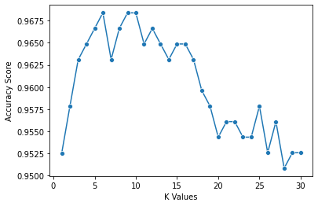

```python
sns.lineplot(x = k_values, y = scores, marker = 'o')
plt.xlabel("K Values")
plt.ylabel("Accuracy Score")

scores.index(max(scores))+1
```

#### Cuestión 6:

Explica los resultados que has obtenido en la gráfica

Como podemos ver en la gráfica si usamos valor 6 para K conseguiremos el máximo accuracy.

### Actividad 5:

Vuelve ahora a entrenar a KNN con el mejor valor de K y obtén los valores de los tres indicadores de calidad para estos parámetros.

Compáralos para los obtenidos la primera vez que hemos probado KNN con un valor de K elegido arbitrariamente e indica las diferencias que encuentras.

```python
X_train, X_test, y_train, y_test = train_test_split(df_datanormalized, ground_truth, test_size=0.2, random_state=37)

knn = KNeighborsClassifier(n_neighbors=6)
knn.fit(X_train, y_train)

Xtest = np.array(X_test)
y_pred = knn.predict(Xtest)
print(y_pred)
#Calculamos la accuracy de la predicion
accuracy = accuracy_score(y_test, y_pred)
print("Accuracy:", accuracy)
#Calculamos la precision de la predicion
precision = precision_score(y_test, y_pred, average=None)
print("Precision: ", precision)
#Calculamos el recall de la predicion
recall = recall_score(y_test, y_pred, average=None)
print("Recall: ", recall)
```

```
['B' 'B' 'B' 'B' 'B' 'B' 'M' 'B' 'B' 'M' 'B' 'B' 'B' 'B' 'M' 'B' 'M' 'M'
 'M' 'B' 'B' 'B' 'B' 'B' 'B' 'M' 'M' 'B' 'M' 'B' 'B' 'M' 'B' 'B' 'B' 'B'
 'B' 'B' 'M' 'M' 'B' 'B' 'B' 'B' 'B' 'B' 'B' 'M' 'B' 'B' 'B' 'M' 'M' 'M'
 'M' 'M' 'B' 'M' 'B' 'B' 'B' 'M' 'B' 'B' 'B' 'B' 'M' 'B' 'B' 'M' 'B' 'B'
 'B' 'B' 'M' 'B' 'M' 'B' 'M' 'B' 'B' 'M' 'B' 'M' 'M' 'M' 'B' 'B' 'B' 'B'
 'M' 'B' 'M' 'B' 'B' 'B' 'B' 'B' 'B' 'B' 'B' 'M' 'B' 'M' 'B' 'B' 'M' 'M'
 'B' 'M' 'M' 'B' 'B' 'B']
Accuracy: 0.9736842105263158
Precision:  [0.96103896 1.        ]
Recall:  [1.    0.925]
```

Los resultado obtenidos utilizando k=6 son mucho mejores que los que hemos conseguido anteriormente.

### Actividad 6:

Como hemos comentado en teoría, en general el uso de los algoritmos (de clasificacion como knn en este caso, y tambien de agrupamiento) están desacoplados de la noción de simularidad que usan para realizar las comparaciones entre datos. Por defecto knn usa la distancia euclídea (L_2 de Minkowski). Vamos a probar KNN con la distancia del coseno para comparar con los resultados anteriores.

Realiza el mismo estudio de parámetros sobre el dataset normalizado pero usando ahora la distancia del coseno. Obtén la gráfica del estudio del parámetro N para esta definición de distancia completando el cuadro de abajo.

**(¿?)** Debes de usar la libreria scipy.spatial.distance (que se importa en la caja de abajo) y el método 'cosine'. Debes incluir esta métrica en el argumento 'metric' en la asignacion de la variable knn

```
[0.8980593075609378, 0.8927806241266885, 0.9051389535786368, 0.912156497438286, 0.9174196553330228, 0.9174351808725353, 0.9209284272628475, 0.9156652693681107, 0.9191585157584227, 0.9191585157584224, 0.915649743828598, 0.9209284272628473, 0.9174041297935103, 0.9244527247321844, 0.9244527247321844, 0…
```

```
16
```

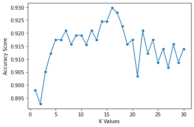

```python
from scipy.spatial import distance

scorel1 =[]
for k in k_values:
    knn = KNeighborsClassifier(n_neighbors=k, metric='cosine')
    score = cross_val_score(knn, df_datanormalized, ground_truth, cv=5)
    scorel1.append(np.mean(score))

print(scorel1)
sns.lineplot(x = k_values, y = scorel1, marker = 'o')
plt.xlabel("K Values")
plt.ylabel("Accuracy Score")

scorel1.index(max(scorel1))+1
```

#### Cuestión 7:

Explica los resultados obtenidos en esta gráfica respecto a la gráfica anterior. Indica cuál de las distancias usadas es la más adecuada. Razona tu respuesta.

La gráfica anterior (utilizando L2) se obtienen mejor resultado porque el valor de máximo de accuracy es mayor que el de la segunda (cosine).